# Arturo_Noguera_prompt

```python
#Although some entries are missing for features like Bar, CoffeHouse, etc;
#we will keep them as they are too few, we will replace missing data with 'Never',
#assuming that these customers did not answer because they do not attend this venues.
data=data.fillna('never')
```

```python
#Missing data has been filled with 'Never' option
#Show the attendance distribution for customers getting a coupon type Bar
data.groupby([ 'Bar'], dropna=False, as_index=False).size()
```

|  | Bar | size |
| --- | --- | --- |
| 0 | 1~3 | 2473 |
| 1 | 4~8 | 1076 |
| 2 | gt8 | 349 |
| 3 | less1 | 3482 |
| 4 | never | 5304 |

```python
#Missing data has been filled with 'Never' option
#Show the attendance distribution for customers getting a coupon type CoffeHouse
data.groupby([ 'CoffeeHouse'], dropna=False, as_index=False).size()
```

|  | CoffeeHouse | size |
| --- | --- | --- |
| 0 | 1~3 | 3225 |
| 1 | 4~8 | 1784 |
| 2 | gt8 | 1111 |
| 3 | less1 | 3385 |
| 4 | never | 3179 |

```python
#Missing data has been filled with 'Never' option
#Show the attendance distribution for customers getting a coupon type CarryAway
data.groupby([ 'CarryAway'], dropna=False, as_index=False).size()
```

|  | CarryAway | size |
| --- | --- | --- |
| 0 | 1~3 | 4672 |
| 1 | 4~8 | 4258 |
| 2 | gt8 | 1594 |
| 3 | less1 | 1856 |
| 4 | never | 304 |

```python
#Missing data has been filled with 'Never' option
#Show the attendance distribution for customers getting a coupon type "Cheap Restaurant"
data.groupby([ 'RestaurantLessThan20'], dropna=False, as_index=False).size()
```

|  | RestaurantLessThan20 | size |
| --- | --- | --- |
| 0 | 1~3 | 5376 |
| 1 | 4~8 | 3580 |
| 2 | gt8 | 1285 |
| 3 | less1 | 2093 |
| 4 | never | 350 |

```python
#Missing data has been filled with 'Never' option
#Show the attendance distribution for customers getting a coupon type "Expensive Restaurant"
data.groupby([ 'Restaurant20To50'], dropna=False, as_index=False).size()
```

|  | Restaurant20To50 | size |
| --- | --- | --- |
| 0 | 1~3 | 3290 |
| 1 | 4~8 | 728 |
| 2 | gt8 | 264 |
| 3 | less1 | 6077 |
| 4 | never | 2325 |

4. What proportion of the total observations chose to accept the coupon?

```python
data['Y'].value_counts()
```

```
Y
1    7210
0    5474
Name: count, dtype: int64
```

```python
print ("Customers proportion accepting the received  coupon is ", round(7210/(7210+4474)*100,2), "%")
```

[output not shown]

5. Use a bar plot to visualize the `coupon` column.

```python
#Breakdown of customers receiving a coupon per coupon type
data['coupon'].value_counts()
```

```
coupon
Coffee House             3996
Restaurant(<20)          2786
Carry out & Take away    2393
Bar                      2017
Restaurant(20-50)        1492
Name: count, dtype: int64
```

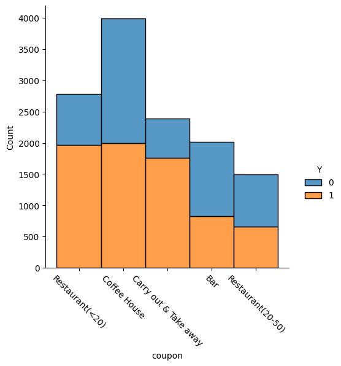

```python
#Seaborn Distribution Plot of customers, per coupon type and colored by acceptance  (Y=1 accepted;  Y=0 not accepted)
sns.displot(data=data, x="coupon", hue="Y",multiple="stack")
plt.xticks(rotation=-45)
plt.show()
```

```python
#Accepted and Not Accepted value count per each coupon type
data_accepted=data[['coupon','Y']].value_counts(sort=False)
```

```python
data_accepted
```

```
coupon                 Y
Bar                    0    1190
                       1     827
Carry out & Take away  0     633
                       1    1760
Coffee House           0    2001
                       1    1995
Restaurant(20-50)      0     834
                       1     658
Restaurant(<20)        0     816
                       1    1970
Name: count, dtype: int64
```

```python
#Insted of use % I am using  the ratio between accepted over not accepted for each coupon type


#Coupon accepted vs not accepted ratio per each coupon type
for rate in  range(5):
    coupon, no_accepted=data_accepted.index[rate*2]
    print (coupon, round(data_accepted.iloc[rate*2+1]/data_accepted.iloc[rate*2],2))
```

```
Bar 0.69
Carry out & Take away 2.78
Coffee House 1.0
Restaurant(20-50) 0.79
Restaurant(<20) 2.41
```

6. Use a histogram to visualize the temperature column.

```python
#I am using Ploty Express to plot a histogram for the temperature and colored by acceptance type
Temp_Dist = px.histogram(data, x='temperature', color='Y', barmode='group',histfunc='count', nbins=10)
Temp_Dist.update_layout(title='Temperature Histogram per Accept Coupon' ,xaxis_title='Temperature', yaxis_title='Count', legend_title='Accept Coupon')
Temp_Dist.show()
```

[interactive chart not shown]

**Investigating the Bar Coupons**

Now, we will lead you through an exploration of just the bar related coupons.

1. Create a new `DataFrame` that contains just the bar coupons.

```python
#we create a new DataFrame exclusively for coupon type equals BAR
data_Bar=data[data['coupon']=='Bar']
```

```python
data_Bar.shape
```

```
(2017, 25)
```

2. What proportion of bar coupons were accepted?

```python
data_Bar['Y'].value_counts()
```

```
Y
0    1190
1     827
Name: count, dtype: int64
```

```python
print ( round(827/(827+1190)*100,3), "percent of Bar coupons were acepted")
```

```
41.001 percent of Bar coupons were acepted
```

3. Compare the acceptance rate between those who went to a bar 3 or fewer times a month to those who went more.

```python
#fron the breakdown below, we will ignore the customers that NEVER go to the Bar to calculate acceptance ratio based in the number of times
#the customer attends to the Bar, otherwise it could create a bias effect

#Create  breakdown of Customers per attendance frequency and acceptance type

data_Bar[['Bar','Y']].value_counts(sort=False)
```

```
Bar    Y
1~3    0    140
       1    257
4~8    0     33
       1    117
gt8    0     13
       1     36
less1  0    317
       1    253
never  0    687
       1    164
Name: count, dtype: int64
```

```python
#based in the Bar categorical variable, we use the shown labels to aproximate the required range
data_Bar.query("Bar==['1~3','less1']")[['Bar','Y']].value_counts(sort=False)
```

```
Bar    Y
1~3    0    140
       1    257
less1  0    317
       1    253
Name: count, dtype: int64
```

```python
print('acceptance RATIO for customers that went to a bar 3 or fewer times a month is ',round((257+253)/(140+317),2) )
```

```
acceptance RATIO for customers that went to a bar 3 or fewer times a month is  1.12
```

```python
#based in the Bar categorical variable, we use the shown labels to aproximate the required range
data_Bar.query("Bar==['4~8','gt8']")[['Bar','Y']].value_counts(sort=False)
```

```
Bar  Y
4~8  0     33
     1    117
gt8  0     13
     1     36
Name: count, dtype: int64
```

```python
print('acceptance ratio for customers that went to a bar more than 3 times a month is',round((117+36)/(33+13),2) )
```

```
acceptance ratio for customers that went to a bar more than 3 times a month is 3.33
```

```python
#Customers that go the bar more than 3 times a month have an acceptance ratio 3 time higher than customer going 3 or less
```

4. Compare the acceptance rate between drivers who go to a bar more than once a month and are over the age of 25 to the all others. Is there a difference?

```python
#a break down for the age feature groups
data_Bar.groupby([ 'age'], dropna=False, as_index=False).size()
```

|  | age | size |
| --- | --- | --- |
| 0 | 21 | 417 |
| 1 | 26 | 395 |
| 2 | 31 | 339 |
| 3 | 36 | 209 |
| 4 | 41 | 178 |
| 5 | 46 | 109 |
| 6 | 50plus | 283 |
| 7 | below21 | 87 |

```python
##based in the Age categorical variable, we use the shown labels to aproximate the required range
#I create a new dataframe for customers over 25
data_Bar_over25=data_Bar.query("age!=['21','below21']")
```

```python
#verify that we have the correct age groups in the new dataframe
data_Bar_over25['age'].value_counts()
```

```
age
26        395
31        339
50plus    283
36        209
41        178
46        109
Name: count, dtype: int64
```

```python
data_Bar_over25.shape
```

```
(1513, 25)
```

```python
#get the acceptance labels for the customers of interest
data_Bar_over25.query("Bar!=['less1','never']")[['Y']].value_counts(sort=False)
```

```
Y
0    128
1    292
Name: count, dtype: int64
```

```python
print("Acceptance RATIO for customers over 25 and going more than once a month to the bar is ",292/128)
```

```
Acceptance RATIO for customers over 25 and going more than once a month to the bar is  2.28125
```

```python
frames=[data_Bar.query("age==['21','below21']"), data_Bar_over25.query("Bar==['less1','never']")]
```

```python
data_Bar_remaining=pd.concat(frames)
```

```python
data_Bar_remaining[['Y']].value_counts(sort=False)
```

```
Y
0    1062
1     535
Name: count, dtype: int64
```

```python
data_Bar_remaining.shape
```

```
(1597, 25)
```

```python
print("Acceptance RATIO for remaining customers is ", round(535/1062,3))
```

```
Acceptance RATIO for remaining customers is  0.504
```

```python
#Comparing both rates,  acceptance for frecuent customers over 25 is 4.5 times larger that for the rest of the customers
```

5. Use the same process to compare the acceptance rate between drivers who go to bars more than once a month and had passengers that were not a kid and had occupations other than farming, fishing, or forestry.

```python
#Brake down of the passanger feature
data_Bar['passanger'].value_counts()
```

```
passanger
Alone        1200
Friend(s)     337
Partner       274
Kid(s)        206
Name: count, dtype: int64
```

```python
#break down of the occupation feature
data_Bar['occupation'].value_counts().head()
```

```
occupation
Unemployed                    301
Student                       251
Computer & Mathematical       232
Sales & Related               178
Education&Training&Library    140
Name: count, dtype: int64
```

```python
#create a new Dataframe including only customers of interest
data_Bar_pass_occup=data_Bar.query("passanger!=['Kid(s)'] & occupation!=['Farming Fishing & Forestry']")
```

```python
#validate the new dataframe has the correct groups
data_Bar_pass_occup['passanger'].value_counts()
```

```
passanger
Alone        1195
Friend(s)     336
Partner       274
Name: count, dtype: int64
```

```python
#validate the new dataframe has the correct groups
data_Bar_pass_occup['occupation'].value_counts().head()
```

```
occupation
Unemployed                    273
Student                       243
Computer & Mathematical       196
Sales & Related               169
Education&Training&Library    113
Name: count, dtype: int64
```

```python
#Get acceptance figures for customers of interest
data_Bar_pass_occup.query("Bar!=['less1','never']")[['Y']].value_counts(sort=False)
```

```
Y
0    158
1    393
Name: count, dtype: int64
```

```python
print ("Acceptance RATIO for drivers who go to bars more than once a month and had passengers that were not a kid and had occupations other than farming, fishing, or forestry is", round(393/158,2))
```

```
Acceptance RATIO for drivers who go to bars more than once a month and had passengers that were not a kid and had occupations other than farming, fishing, or forestry is 2.49
```

6. Compare the acceptance rates between those drivers who:
- go to bars more than once a month, had passengers that were not a kid, and were not widowed *OR*
- go to bars more than once a month and are under the age of 30 *OR*
- go to cheap restaurants more than 4 times a month and income is less than 50K.

```python
#Analiss for customers going to bars more than once a month, had passengers that were not a kid, and were not widowed
```

```python
data_Bar['maritalStatus'].value_counts()
```

```
maritalStatus
Married partner      882
Single               661
Unmarried partner    378
Divorced              75
Widowed               21
Name: count, dtype: int64
```

```python
data_Bar_pass_nwidow=data_Bar.query("passanger!=['Kid(s)'] & maritalStatus!=['Widowed']")
```

```python
data_Bar_pass_nwidow['passanger'].value_counts()
```

```
passanger
Alone        1187
Friend(s)     330
Partner       273
Name: count, dtype: int64
```

```python
data_Bar_pass_nwidow['maritalStatus'].value_counts()
```

```
maritalStatus
Married partner      710
Single               656
Unmarried partner    355
Divorced              69
Name: count, dtype: int64
```

```python
data_Bar_pass_nwidow.query("Bar!=['less1','never']")[['Y']].value_counts(sort=False)
```

```
Y
0    158
1    393
Name: count, dtype: int64
```

```python
print ("Acceptance RATIO for customers that go to bars more than once a month, had passengers that were not a kid, and were not widowed is",round(393/158,2))
```

```
Acceptance RATIO for customers that go to bars more than once a month, had passengers that were not a kid, and were not widowed is 2.49
```

```python
#Analisis for customers going to bars more than once a month and are under the age of 30
```

```python
data_Bar_under30=data_Bar.query("age==['21','below21','26']")
```

```python
data_Bar_under30['age'].value_counts()
```

```
age
21         417
26         395
below21     87
Name: count, dtype: int64
```

```python
data_Bar_under30.query("Bar!=['less1','never']")[['Y']].value_counts(sort=False)
```

```
Y
0     96
1    249
Name: count, dtype: int64
```

```python
print ("Acceptance ratio for customers that go to bars more than once a month and are under the age of 30 is",249/96)
```

```
Acceptance ratio for customers that go to bars more than once a month and are under the age of 30 is 2.59375
```

```python
#Analisis for customers going to cheap restaurants more than 4 times a month and income is less than 50K
```

```python
data_Bar['RestaurantLessThan20'].value_counts()
```

```
RestaurantLessThan20
1~3      878
4~8      568
less1    325
gt8      186
never     60
Name: count, dtype: int64
```

```python
data_Bar['income'].value_counts().sort_index()
```

```
income
$100000 or More     291
$12500 - $24999     288
$25000 - $37499     318
$37500 - $49999     267
$50000 - $62499     262
$62500 - $74999     130
$75000 - $87499     151
$87500 - $99999     145
Less than $12500    165
Name: count, dtype: int64
```

```python
data_Bar_cheap_income=data_Bar.query("RestaurantLessThan20==['4~8','gt8'] & income==['Less than $12500','$12500 - $24999','$25000 - $37499','$37500 - $49999']")
```

```python
data_Bar_cheap_income['income'].value_counts()
```

```
income
$12500 - $24999     99
$37500 - $49999     98
$25000 - $37499     74
Less than $12500    73
Name: count, dtype: int64
```

```python
data_Bar_cheap_income['RestaurantLessThan20'].value_counts()
```

```
RestaurantLessThan20
4~8    248
gt8     96
Name: count, dtype: int64
```

```python
data_Bar_cheap_income[['Y']].value_counts(sort=False)
```

```
Y
0    188
1    156
Name: count, dtype: int64
```

```python
print ("Acceptance ratio for customers that go to cheap restaurants more than 4 times a month and income is less than 50K is",round(156/188,2))
```

```
Acceptance ratio for customers that go to cheap restaurants more than 4 times a month and income is less than 50K is 0.83
```

7. Based on these observations, what do you hypothesize about drivers who accepted the bar coupons?

```python
'''
2017 customers got the Bar coupon

Out of these only 827  (41%) accepted the coupon

From customers that received the Bar coupon,  those who go to bar more than 3 times a month, have an acceptance ratio (accepted/not accepted) equals to 3.3  while customers going to a bar 3 or fewer times a month. have an accpetance ratio equals to 1.1.
That is frequent bar customers, have an acceptance ratio 3 times higher thatn unfrecuent customers.

Customers over 25 who go to bar more than once a month have an accpetance ratio equals to 2.28, while the rest of the customers having the bar coupon have an acceptance ratio equals to 0.50.
That is frequent customers over 25, have an acceptance ratio 4.5 times higher than the rest of the customers.

drivers who go to bars more than once a month and had passengers that were not a kid and had occupations other than farming, fishing, or forestry have an acceptance ratio equals  around 2.5,
that is more than 70% of these customers accept the coupon.

The sane acceptance ratio (2.5) shows up for customers that go to bars more than once a month, had passengers that were not a kid, and were not widowed.

For customers that go to bars more than once a month and are under the age of 30 ,the acceptance ratio is 2.59

On the other side , customers that got the bar coupon and go to cheap restaurants more than 4 times a month and income is less than 50K, are less likely to accept the coupon, their acceptance ratio us 0.83,

'''
```

```
'\n2017 customers got the Bar coupon\n\nOut of these only 827  (41%) accepted the coupon\n\nFrom customers that received the Bar coupon,  those who go to bar more than 3 times a month, have an acceptance ratio (accepted/not accepted) equals to 3.3  while customers going to a bar 3 or fewer times a m…
```

### Independent Investigation

Using the bar coupon example as motivation, you are to explore one of the other coupon groups and try to determine the characteristics of passengers who accept the coupons.

```python
#I will explore the coupon group "Coffee House" as it is the group with 50/50  acceptance rate, ratio=0.997
```

```python
data.info()
```

```
<class 'pandas.core.frame.DataFrame'>
RangeIndex: 12684 entries, 0 to 12683
Data columns (total 25 columns):
 #   Column                Non-Null Count  Dtype
---  ------                --------------  -----
 0   destination           12684 non-null  object
 1   passanger             12684 non-null  object
 2   weather               12684 non-null  object
 3   temperature           12684 non-null  int64
 4   time                  12684 non-null  object
 5   coupon                12684 non-null  object
 6   expiration            12684 non-null  object
 7   gender                12684 non-null  object
 8   age                   12684 non-null  object
 9   maritalStatus         12684 non-null  object
```

[output cut: 17 more lines]

```python
data['coupon'].value_counts()
```

```
coupon
Coffee House             3996
Restaurant(<20)          2786
Carry out & Take away    2393
Bar                      2017
Restaurant(20-50)        1492
Name: count, dtype: int64
```

```python
data_Coffee=data[data['coupon']=='Coffee House']
```

```python
data_Coffee.shape
```

```
(3996, 25)
```

```python
#Value count for Acceptance feature for Customers with "Coffe" coupon
data_Coffee[['Y']].value_counts(sort=False)
```

```
Y
0    2001
1    1995
Name: count, dtype: int64
```

```python
print ( round(1995/(1995+2001)*100,3), "percent of CoffeHouse coupons were acepted")
```

```
49.925 percent of CoffeHouse coupons were acepted
```

```python
#Acceptance ratio for Customers with "Coffe" coupon is  1995/2001= 0.997
```

```python
#Distribution for attendace frequency for Customers with "Coffe" coupon
data_Coffee['CoffeeHouse'].value_counts()
```

```
CoffeeHouse
less1    1075
1~3      1042
never     999
4~8       538
gt8       342
Name: count, dtype: int64
```

```python
#Lest Compare the acceptance rate between those who went to a CoffeShop 3 or fewer times a month to those who went more
```

```python
##Distribution for attendace frequency and acceptance ratio for Customers with "Coffe" coupon
data_Coffee[['CoffeeHouse','Y']].value_counts(sort=False)
```

```
CoffeeHouse  Y
1~3          0    367
             1    675
4~8          0    169
             1    369
gt8          0    117
             1    225
less1        0    557
             1    518
never        0    791
             1    208
Name: count, dtype: int64
```

```python
#we can see that those customers going to the coffe shop  frequently have a 2:1 acceptance ratio
#however customers attending less than once a month or never have the lowest acceptance ratio (1:1 or 1:4)
```

```python
data_Coffee.query("CoffeeHouse==['4~8','gt8']")[['Y']].value_counts(sort=False)
```

```
Y
0    286
1    594
Name: count, dtype: int64
```

```python
data_Coffee.query("CoffeeHouse==['1~3','less1']")[['Y']].value_counts(sort=False)
```

```
Y
0     924
1    1193
Name: count, dtype: int64
```

```python
print ("The coupon aceptance ratio for frequent customers is ",594/286, ", for less frequent customer is ", round(1193/924,2))
```

```
The coupon aceptance ratio for frequent customers is  2.076923076923077 , for less frequent customer is  1.29
```

```python
#Lets explore the acceptance ratio for customers with Coffee coupon and top 3 occupations.
data_Coffee.query("occupation==['Unemployed','Student','Computer & Mathematical']")[['occupation','Y']].value_counts(sort=False)
```

```
occupation               Y
Computer & Mathematical  0    223
                         1    226
Student                  0    187
                         1    312
Unemployed               0    261
                         1    309
Name: count, dtype: int64
```

```python
# most of the customers get the coupon if the weather is Sunny, however the acceptance ratio remains close to 1 for all weathers.
data_Coffee[['weather','Y']].value_counts()
```

```
weather  Y
Sunny    1    1746
         0    1721
Snowy    0     172
         1     131
Rainy    1     118
         0     108
Name: count, dtype: int64
```

```python
#50% of  the customers accept the coupon even if the Coffee shop is in opposite direction , maybe they will attend coming back to their home
#Look like the acceptance ratio remains 1:1 regarless of the direction
data_Coffee[['direction_same','direction_opp','Y']].value_counts()
```

```
direction_same  direction_opp  Y
0               1              0    1649
                               1    1597
1               0              1     398
                               0     352
Name: count, dtype: int64
```

```python
#Customers between 21 and 30 are the ones with higer  frequency
data_Coffee.groupby([ 'age'], dropna=False, as_index=False).size()
```

|  | age | size |
| --- | --- | --- |
| 0 | 21 | 883 |
| 1 | 26 | 843 |
| 2 | 31 | 623 |
| 3 | 36 | 402 |
| 4 | 41 | 325 |
| 5 | 46 | 220 |
| 6 | 50plus | 545 |
| 7 | below21 | 155 |

```python
#Lets explore the acceptance ratio based in the age group
data_Coffee_age=data_Coffee[['age','Y']].value_counts(sort=False)
```

```python
for rate in  range(8):
    age, no_accepted=data_Coffee_age.index[rate*2]
    print (age,round (data_Coffee_age.iloc[rate*2+1]/data_Coffee_age.iloc[rate*2],2))
```

```
21 1.1
26 1.06
31 0.91
36 0.88
41 1.01
46 1.06
50plus 0.72
below21 2.3
```

```python
#Althoug below21 is the group with lowest frequency, it has the higher acceptance ratio.
```

```python
#In summary
#customers going to the coffe shop  frequently have a 2:1 acceptance ratio
#however customers attending less than once a month or never have the lowest acceptance ratio (1:1 and 1:4 respectively.)
#the weather has not direct impact on the acceptance ratio, however the couponts are sent mostly in sunny weather
#the occupation feature for the top frequencies "Student" and "Unemployed" are 1.7 and 1.1 respectively.
#travel direction  has no huge impact on the acceptance rate
#Acceptance ratio for each age group remains close to the media (1:1)for most groups, except the two ouliers (below21 with 2.3 and 50plus with 0.72)
```